# DTSA_5511_Deep_Learning_Final_Project

**Problem Statement**

In this assignment, I implemented a deep learning Convolutional Neural Network (CNN) to identify whether a medical scan image does or does not contain a cancerous tumor. Using a multi-layered CNN with convolution, pooling, normalization, and flattening components, I achieved up to 88% accuracy and 65% testing accuracy in my best set of hyperparameter tuning. This degree of accuracy wouldn't be adequate as a substitute for proper medical review of lymph node scans, but it does demonstrate the CNN being able to capture at least some of the statistical signatures of cancer.

**Exploratory Data Analysis**

Before training my CNN model, I first performed an exploratory data analysis on the data set. Since the data came from a Kaggle competition (Reference 1), it was already in a relatively usable format. I didn't have to remove outliers or normalize in any way. Initially, I did look at the ratio of positive/negative samples to assess the degree to which the data set was imbalanced. It was not significantly so. Then, I plotted a handful of the images. It was not apparent to me (someone with no medical training) which ones had the cancer, but that's what the CNN will be for.

```python
import pandas as pd
import numpy as np
import os
from glob import glob
from skimage.io import imread
import matplotlib.pyplot as plt
from PIL import Image
from tensorflow import keras
from tensorflow.keras import layers
from tensorflow.keras.models import Sequential
import tensorflow as tf
from sklearn.model_selection import train_test_split
from tensorflow.keras.preprocessing.image import ImageDataGenerator
```

```python
from google.colab import drive
drive.mount('/content/drive')
```

```python
print(os.listdir('/content/drive/My Drive/DTSA 5511'))
```

```
['train_labels.csv', 'histopathologic-cancer-detection.zip', 'testing upload', 'model0.keras', 'model.keras', 'r0.csv', 'r.csv']
```

```python
import zipfile
zf = zipfile.ZipFile('/content/drive/My Drive/DTSA 5511/histopathologic-cancer-detection.zip','r')
zf.extractall('/content')
zf.close()
```

```
0    130908
1     89117
Name: label, dtype: int64
```

```
<BarContainer object of 2 artists>
```

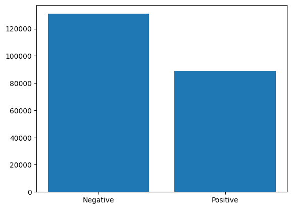

```python
labels = pd.read_csv('/content/drive/My Drive/DTSA 5511/train_labels.csv')
labels['id'] = labels['id'].apply(lambda x: os.path.join('/content/train', x + '.tif'))
# Split the data into training and validation sets
lc = labels['label'].value_counts()
print(lc)
plt.bar(['Negative','Positive'],lc.values)
```

```
Label =  0
```

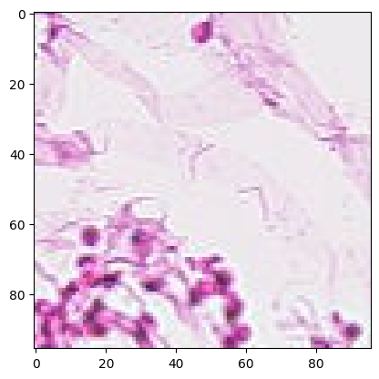

```python
image_directories = [os.path.join('/content/train', i) for i in os.listdir('/content/train')]
print('Label = ', labels['label'][0])
image = Image.open(image_directories[0])
plt.imshow(image)
```

```
Label =  1
```

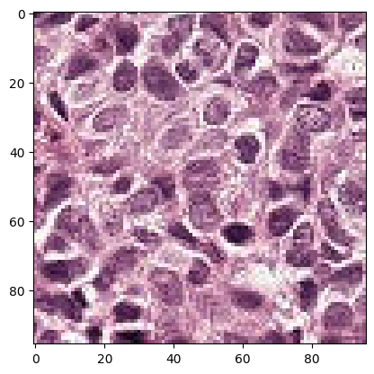

```python
print('Label = ', labels['label'][1])
image = Image.open(image_directories[1])
plt.imshow(image)
```

```
Label =  0
```

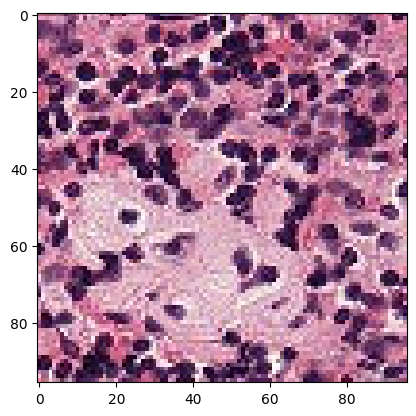

```python
print('Label = ', labels['label'][2])
image = Image.open(image_directories[2])
plt.imshow(image)
```

```
Label =  0
```

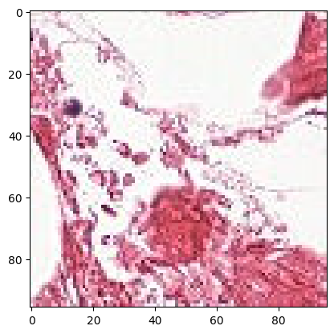

```python
print('Label = ', labels['label'][3])
image = Image.open(image_directories[3])
plt.imshow(image)
```

```
Label =  0
```

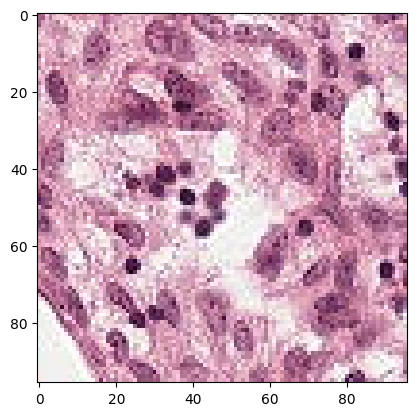

```python
print('Label = ', labels['label'][4])
image = Image.open(image_directories[4])
plt.imshow(image)
```

```
Label =  1
```

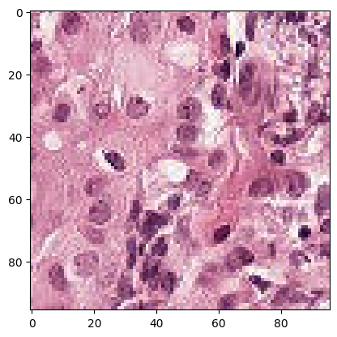

```python
print('Label = ', labels['label'][6])
image = Image.open(image_directories[6])
plt.imshow(image)
```

**Modeling Building and Training**

Next, I built a CNN that I trained on the training data set. In terms of CNN layer structure and ordering, I initally followed the Tensor Flow tutorial (Reference 6) and then experimented with my own modifications. For hyperparameter tuning, I compared a simpler model with 8, 16, 32, and 64 sized filters with a more involve model that doubled the number of 8-filter CNN layers and included more batch normalization and pooling. I hypothesized that the more complex model would perform better, and I specifically focused on making my additional layer being a coarser rather than a finer convolution since I didn't want it to overfit.

```python
train_df, test_df = train_test_split(labels, test_size=0.3)
train_datagen = ImageDataGenerator(rescale=1./255)
test_datagen = ImageDataGenerator(rescale=1./255)

train_generator = train_datagen.flow_from_dataframe(
    train_df,
    x_col = 'id',
    y_col = 'label',
    class_mode = 'raw'
    batch_size = 32,
    target_size = (96, 96)
)

test_generator = train_datagen.flow_from_dataframe(
    test_df,
    x_col = 'id',
    y_col = 'label',
    class_mode = 'raw'
    batch_size = 32,
    target_size = (96, 96)
)
```

[output not shown]

```python
model0 = Sequential([
  layers.Rescaling(1./255, input_shape=(96, 96, 3)),
  layers.Conv2D(8, (3,3), activation='relu'),
  layers.Conv2D(16, (3,3), activation='relu'),
  layers.BatchNormalization(),
  layers.MaxPooling2D(pool_size=(3,3)),

  layers.Conv2D(32, (3,3), activation='relu'),

  layers.Conv2D(64, (3,3), activation='relu'),
  layers.BatchNormalization(),
  layers.MaxPooling2D(pool_size=(3,3)),

  layers.Flatten(),

  layers.Dense(64, activation='sigmoid'),
  layers.Dense(2, activation = 'softmax')
])

model0.compile(optimizer='adam',
              loss=tf.keras.losses.SparseCategoricalCrossentropy(from_logits=True),
              metrics=['accuracy'])

model0.summary()
```

```
Model: "sequential"
_________________________________________________________________
 Layer (type)                Output Shape              Param #
=================================================================
 rescaling (Rescaling)       (None, 96, 96, 3)         0

 conv2d (Conv2D)             (None, 94, 94, 8)         224

 conv2d_1 (Conv2D)           (None, 92, 92, 16)        1168

 batch_normalization (Batch  (None, 92, 92, 16)        64
 Normalization)

 max_pooling2d (MaxPooling2  (None, 30, 30, 16)        0
 D)

 conv2d_2 (Conv2D)           (None, 28, 28, 32)        4640

 conv2d_3 (Conv2D)           (None, 26, 26, 64)        18496

 batch_normalization_1 (Bat  (None, 26, 26, 64)        256
 chNormalization)

 max_pooling2d_1 (MaxPoolin  (None, 8, 8, 64)          0
 g2D)

 flatten (Flatten)           (None, 4096)              0

 dense (Dense)               (None, 64)                262208

 dense_1 (Dense)             (None, 2)                 130

=================================================================
Total params: 287186 (1.10 MB)
Trainable params: 287026 (1.09 MB)
Non-trainable params: 160 (640.00 Byte)
_________________________________________________________________
```

```python
model = Sequential([
  layers.Rescaling(1./255, input_shape=(96, 96, 3)),
  layers.Conv2D(8, (3,3), activation='relu'),
  layers.Conv2D(8, (3,3), activation='relu'),

  layers.Conv2D(16, (3,3), activation='relu'),
  layers.BatchNormalization(),
  layers.MaxPooling2D(pool_size=(3,3)),

  layers.Conv2D(32, (3,3), activation='relu'),
  layers.BatchNormalization(),
  layers.MaxPooling2D(pool_size=(3,3)),

  layers.Conv2D(64, (3,3), activation='relu'),
  layers.BatchNormalization(),
  layers.MaxPooling2D(pool_size=(3,3)),

  layers.Flatten(),

  layers.Dense(64, activation='sigmoid'),
  layers.Dense(2, activation = 'softmax')
])

model.compile(optimizer='adam',
              loss=tf.keras.losses.SparseCategoricalCrossentropy(from_logits=True),
              metrics=['accuracy'])

model.summary()
```

```
Model: "sequential"
_________________________________________________________________
 Layer (type)                Output Shape              Param #
=================================================================
 rescaling (Rescaling)       (None, 96, 96, 3)         0

 conv2d (Conv2D)             (None, 94, 94, 8)         224

 conv2d_1 (Conv2D)           (None, 92, 92, 8)         584

 conv2d_2 (Conv2D)           (None, 90, 90, 16)        1168

 batch_normalization (Batch  (None, 90, 90, 16)        64
 Normalization)

 max_pooling2d (MaxPooling2  (None, 30, 30, 16)        0
 D)

 conv2d_3 (Conv2D)           (None, 28, 28, 32)        4640

 batch_normalization_1 (Bat  (None, 28, 28, 32)        128
 chNormalization)

 max_pooling2d_1 (MaxPoolin  (None, 9, 9, 32)          0
 g2D)

 conv2d_4 (Conv2D)           (None, 7, 7, 64)          18496

 batch_normalization_2 (Bat  (None, 7, 7, 64)          256
 chNormalization)

 max_pooling2d_2 (MaxPoolin  (None, 2, 2, 64)          0
 g2D)

 flatten (Flatten)           (None, 256)               0

 dense (Dense)               (None, 64)                16448

 dense_1 (Dense)             (None, 2)                 130

=================================================================
Total params: 42138 (164.60 KB)
Trainable params: 41914 (163.73 KB)
Non-trainable params: 224 (896.00 Byte)
_________________________________________________________________
```

```python
results0 = model0.fit(
    train_generator,
    steps_per_epoch=len(train_df)/32,
    epochs=10,
    validation_data=test_generator,
    validation_steps=len(test_df)/32)

model0.save('/content/drive/My Drive/DTSA 5511/model0.keras')

results = model.fit(
    train_generator,
    steps_per_epoch=len(train_df)/32,
    epochs=10,
    validation_data=test_generator,
    validation_steps=len(test_df)/32)

model.save('/content/drive/My Drive/DTSA 5511/model.keras')

r0 = pd.DataFrame(results0.history)
r0.to_csv('/content/drive/My Drive/DTSA 5511/r0.csv')

r = pd.DataFrame(results.history)
r.to_csv('/content/drive/My Drive/DTSA 5511/r.csv')
```

**Results**

```python
recovered_model = keras.models.load_model('/content/drive/My Drive/DTSA 5511/model.keras')
#model.save('/content/drive/My Drive/DTSA 5511/model.keras')
```

```
dict_keys(['loss', 'accuracy', 'val_loss', 'val_accuracy'])
[0.8480557203292847, 0.8596063852310181, 0.8602167367935181, 0.8569378852844238, 0.8268502950668335, 0.8537044525146484, 0.8655992746353149, 0.8393359184265137, 0.8431147336959839, 0.8460364937782288]
```

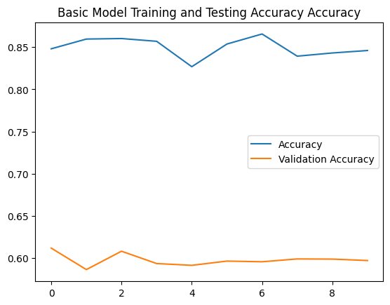

```python
print(results0.history.keys())
print(results0.history['accuracy'])
plt.plot(results0.history['accuracy'], label = 'Training Accuracy')
plt.plot(results0.history['val_accuracy'], label = 'Testing Accuracy')
plt.title('Basic Model Training and Testing Accuracy Accuracy')
plt.legend(["Accuracy","Validation Accuracy"])
#plt.ylim([0,1])
```

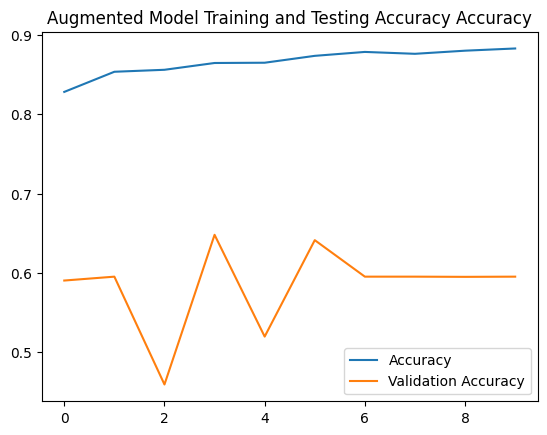

```python
results = pd.read_csv('/content/drive/My Drive/DTSA 5511/r.csv')#reimporting since my Google Colab runtime environment had to restart
#print(results)
#print(results.history.keys())
#print(results.history['accuracy'])
plt.plot(results['accuracy'], label = 'Training Accuracy')
plt.plot(results['val_accuracy'], label = 'Testing Accuracy')
plt.title('Augmented Model Training and Testing Accuracy Accuracy')
plt.legend(["Accuracy","Validation Accuracy"])
#plt.ylim([0,1])
```

```python
labels_test = pd.DataFrame(0,index=np.arange(57458),columns = ["id","label"])
labels_test = labels_test

labels_test['id'] = labels['id'].apply(lambda x: os.path.join('/content/test', x))
t_generator = train_datagen.flow_from_dataframe(
    labels_test,
    x_col='id',
    y_col='label',
    target_size=(96, 96),
    class_mode='raw',
    batch_size=57458
)
print(labels_test['id'][0])
print(labels_test)
```

```
Found 57458 validated image filenames.
/content/train/f38a6374c348f90b587e046aac6079959adf3835.tif
                                                      id  label
0      /content/train/f38a6374c348f90b587e046aac60799...      0
1      /content/train/c18f2d887b7ae4f6742ee445113fa1a...      0
2      /content/train/755db6279dae599ebb4d39a9123cce4...      0
3      /content/train/bc3f0c64fb968ff4a8bd33af6971eca...      0
4      /content/train/068aba587a4950175d04c680d38943f...      0
...                                                  ...    ...
57453  /content/train/7c0e7df0185123cafe14b9cc73fb205...      0
57454  /content/train/beb30ce734fba87876e7136ad514c86...      0
57455  /content/train/e351f438f87bf087c581fae3f909d7d...      0
57456  /content/train/0cd0620b5b69dd73ea386174b3bd174...      0
57457  /content/train/7121e8350481806b2c03d99d3b1e6aa...      0

[57458 rows x 2 columns]
```

```python
test_generator=test_datagen.flow_from_dataframe(
dataframe=labels_test,
directory="/content/test",
x_col='id',
y_col=None,
batch_size=1,
seed=42,
shuffle=False,
class_mode=None,
target_size=(96,96))

test_generator.reset()
#test_generator.n//test_generator.batch_size
pred = recovered_model.predict_generator(test_generator, steps = 57458, verbose = 1)
```

```
Found 57458 validated image filenames.
```

```python
pc = pred.argmax(axis=-1) #the predict_generator output is a list of lists, where each elements are the probabilities of each class. This code turns it into a final predction value
#print(len(pc))
lt = labels_test
lt['label'] = pc
#print(lt)
lt.to_csv('/content/drive/My Drive/DTSA 5511/kaggle_submission.csv')
```

**Discussion and Conclusion**

**References:**

- https://www.kaggle.com/competitions/histopathologic-cancer-detection/overview
- https://stackoverflow.com/questions/48376580/how-to-read-data-in-google-colab-from-my-google-drive
- https://www.geeksforgeeks.org/bar-plot-in-matplotlib/
- https://www.geeksforgeeks.org/python-os-listdir-method/
- https://www.geeksforgeeks.org/python-pil-image-open-method/
- https://www.tensorflow.org/tutorials/images/classification
- https://www.tutorialspoint.com/convert-an-image-into-jpg-format-using-pillow-in-python
- https://stackoverflow.com/questions/45806669/how-to-use-predict-generator-with-imagedatagenerator
- https://datascience.stackexchange.com/questions/32194/how-to-predict-class-label-from-class-probability-given-by-predict-generator-for
- https://www.tensorflow.org/api_docs/python/tf/keras/preprocessing/image/ImageDataGenerator